# Seagle CH 3-4 Test

Adam Seagle

4/19/2020

```r
library(ggplot2)
library(dplyr)
library(readxl)
library(GGally)
CF <- read.csv("CFB2018completeISLR.csv")
```

```r
library(tidyverse)
cfb <- CF %>% select(4,6,7,9,12,13,15,18,19,21,24,25,27,30,31,33)
```

```r
cor(cfb)
```

```
##            Zsagarin   Fr5star   Fr4star     Fravg   So5star   So4star     Soavg
## Zsagarin  1.0000000 0.4084734 0.5003834 0.5680849 0.3935113 0.4840670 0.5350332
## Fr5star   0.4084734 1.0000000 0.5500923 0.6364526 0.5162283 0.5450391 0.5281979
## Fr4star   0.5003834 0.5500923 1.0000000 0.8658820 0.5647797 0.7585371 0.7526044
## Fravg     0.5680849 0.6364526 0.8658820 1.0000000 0.5534153 0.7650569 0.8415504
## So5star   0.3935113 0.5162283 0.5647797 0.5534153 1.0000000 0.5753084 0.6447849
## So4star   0.4840670 0.5450391 0.7585371 0.7650569 0.5753084 1.0000000 0.8687540
## Soavg     0.5350332 0.5281979 0.7526044 0.8415504 0.6447849 0.8687540 1.0000000
## Jr5star   0.3593669 0.5334440 0.5531131 0.5484128 0.5179655 0.5804721 0.5593139
## Jr4star   0.4896858 0.5169379 0.7257650 0.7275800 0.5506332 0.7459375 0.7598581
## Jravg     0.5247064 0.5216432 0.7332500 0.8068527 0.5362850 0.7508540 0.8427332
## Sr5star   0.3200541 0.5605770 0.5058338 0.5374715 0.5289385 0.5521571 0.5388585
## Sr4star   0.4681156 0.5307469 0.7236196 0.7162827 0.5325513 0.7147785 0.7211758
## Sravg     0.4945389 0.5260415 0.7073293 0.7800907 0.5293559 0.7193395 0.8035797
## Rssr5star 0.3160341 0.4486293 0.5348438 0.5142049 0.5708389 0.5108767 0.5320084
## Rssr4star 0.4549736 0.5393835 0.7190570 0.7178201 0.5366283 0.7043785 0.7073511
## Rssravg   0.4766189 0.4890127 0.7115329 0.7543361 0.5427135 0.7021862 0.7741438
##             Jr5star   Jr4star     Jravg   Sr5star   Sr4star     Sravg Rssr5star
## Zsagarin  0.3593669 0.4896858 0.5247064 0.3200541 0.4681156 0.4945389 0.3160341
## Fr5star   0.5334440 0.5169379 0.5216432 0.5605770 0.5307469 0.5260415 0.4486293
## Fr4star   0.5531131 0.7257650 0.7332500 0.5058338 0.7236196 0.7073293 0.5348438
## Fravg     0.5484128 0.7275800 0.8068527 0.5374715 0.7162827 0.7800907 0.5142049
## So5star   0.5179655 0.5506332 0.5362850 0.5289385 0.5325513 0.5293559 0.5708389
## So4star   0.5804721 0.7459375 0.7508540 0.5521571 0.7147785 0.7193395 0.5108767
## Soavg     0.5593139 0.7598581 0.8427332 0.5388585 0.7211758 0.8035797 0.5320084
## Jr5star   1.0000000 0.5838474 0.6451079 0.5167329 0.5461909 0.5363209 0.5060906
## Jr4star   0.5838474 1.0000000 0.8730071 0.5716822 0.7453881 0.7469548 0.5464863
## Jravg     0.6451079 0.8730071 1.0000000 0.5590848 0.7625346 0.8486817 0.5323533
## Sr5star   0.5167329 0.5716822 0.5590848 1.0000000 0.5724455 0.6382369 0.4984423
## Sr4star   0.5461909 0.7453881 0.7625346 0.5724455 1.0000000 0.8662682 0.5633627
## Sravg     0.5363209 0.7469548 0.8486817 0.6382369 0.8662682 1.0000000 0.5477601
## Rssr5star 0.5060906 0.5464863 0.5323533 0.4984423 0.5633627 0.5477601 1.0000000
## Rssr4star 0.5422985 0.7129955 0.7301232 0.5422392 0.7408951 0.7557438 0.5685787
## Rssravg   0.5331867 0.7195668 0.8044987 0.5288811 0.7411761 0.8373534 0.6378523
##           Rssr4star   Rssravg
## Zsagarin  0.4549736 0.4766189
## Fr5star   0.5393835 0.4890127
## Fr4star   0.7190570 0.7115329
## Fravg     0.7178201 0.7543361
## So5star   0.5366283 0.5427135
## So4star   0.7043785 0.7021862
## Soavg     0.7073511 0.7741438
## Jr5star   0.5422985 0.5331867
## Jr4star   0.7129955 0.7195668
## Jravg     0.7301232 0.8044987
## Sr5star   0.5422392 0.5288811
## Sr4star   0.7408951 0.7411761
## Sravg     0.7557438 0.8373534
## Rssr5star 0.5685787 0.6378523
## Rssr4star 1.0000000 0.8673176
## Rssravg   0.8673176 1.0000000
```

Based on the correlation matrix values above the single best predictor of Zsagarin, based on the potential predictors, is the Fravg predictor. I can tell this because Fravg has the hoghest correlation with the Zsagarin variable with a correlation of 0.568.

```r
CFmr <- lm(Zsagarin ~ Fravg + Soavg + Jravg, data = CF)
summary(CFmr)
```

```
##
## Call:
## lm(formula = Zsagarin ~ Fravg + Soavg + Jravg, data = CF)
##
## Residuals:
##      Min       1Q   Median       3Q      Max
## -2.38042 -0.54787 -0.00697  0.54966  2.28247
##
## Coefficients:
##             Estimate Std. Error t value Pr(>|t|)
## (Intercept)  -4.0896     0.1987 -20.581  < 2e-16 ***
## Fravg         0.8004     0.1220   6.560 9.32e-11 ***
## Soavg         0.2659     0.1329   2.001   0.0457 *
## Jravg         0.2971     0.1220   2.435   0.0151 *
## ---
## Signif. codes:  0 '***' 0.001 '**' 0.01 '*' 0.05 '.' 0.1 ' ' 1
##
## Residual standard error: 0.8019 on 853 degrees of freedom
## Multiple R-squared:  0.3384, Adjusted R-squared:  0.3361
## F-statistic: 145.5 on 3 and 853 DF,  p-value: < 2.2e-16
```

```r
CFmr2 <- lm(Zsagarin ~ Fravg + Soavg + Jravg + conference, data = CF)
summary(CFmr2)
```

```
##
## Call:
## lm(formula = Zsagarin ~ Fravg + Soavg + Jravg + conference, data = CF)
##
## Residuals:
##      Min       1Q   Median       3Q      Max
## -2.41084 -0.54008  0.00379  0.56381  2.17361
##
## Coefficients:
##                     Estimate Std. Error t value Pr(>|t|)
## (Intercept)         -4.24377    0.24313 -17.455  < 2e-16 ***
## Fravg                0.81348    0.12282   6.623 6.24e-11 ***
## Soavg                0.27514    0.13304   2.068   0.0389 *
## Jravg                0.29856    0.12250   2.437   0.0150 *
## conferenceBigeast    0.11930    0.10469   1.140   0.2548
## conferencebigten     0.02116    0.09142   0.231   0.8170
## conferencebigtwelve  0.24005    0.09536   2.517   0.0120 *
## conferenceInd       -0.33661    0.24372  -1.381   0.1676
## conferencepacten     0.05788    0.09407   0.615   0.5385
## conferenceSEC        0.12138    0.09312   1.304   0.1928
## ---
## Signif. codes:  0 '***' 0.001 '**' 0.01 '*' 0.05 '.' 0.1 ' ' 1
##
## Residual standard error: 0.7994 on 847 degrees of freedom
## Multiple R-squared:  0.3472, Adjusted R-squared:  0.3403
## F-statistic: 50.06 on 9 and 847 DF,  p-value: < 2.2e-16
```

Once I added the conference predictor to my model, I found that my R-squared value went up slightly but my F-statistic went down quite a bit. I believe this happened due to only one of the conferences being statistically significant while the others have very high p-values. I also saw that this left two of my three original predictors (Fravg and Jravg) with roughly the same p-value but decreases the p-value of my Soavg predictor.

```r
library(car)
vif(CFmr2)
```

```
##                GVIF Df GVIF^(1/(2*Df))
## Fravg      3.939362  1        1.984783
## Soavg      4.690956  1        2.165861
## Jravg      3.946007  1        1.986456
## conference 1.438694  6        1.030775
```

For my model the Variance Inflation Factors are all below 5 so they are not concerning to me when I look at them. This tells me there is not siginificant multicollinearity within my model.

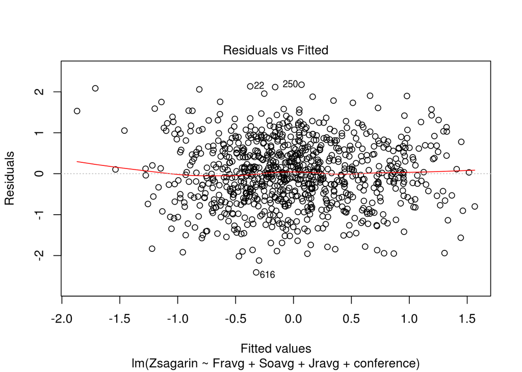

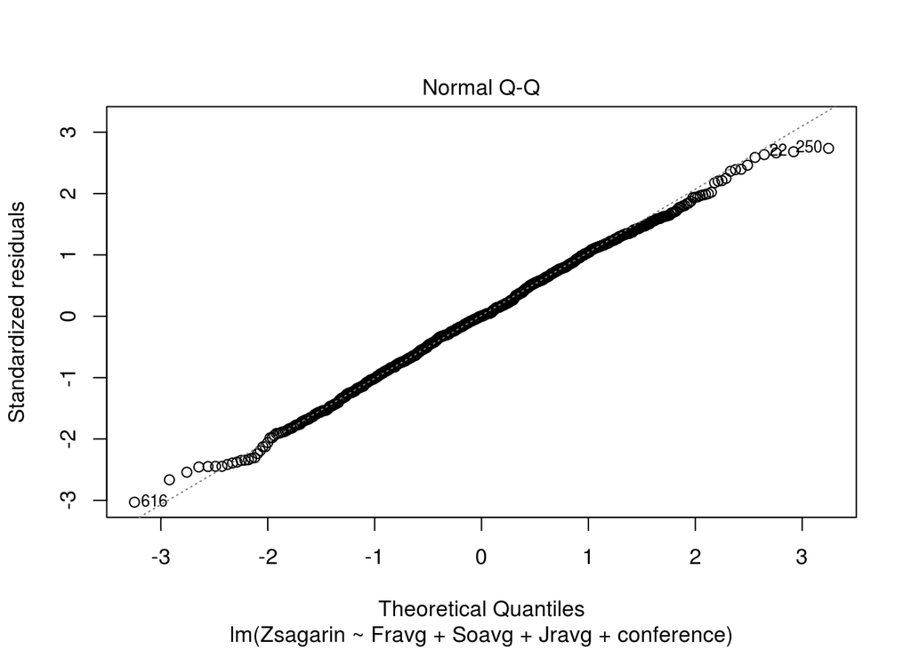

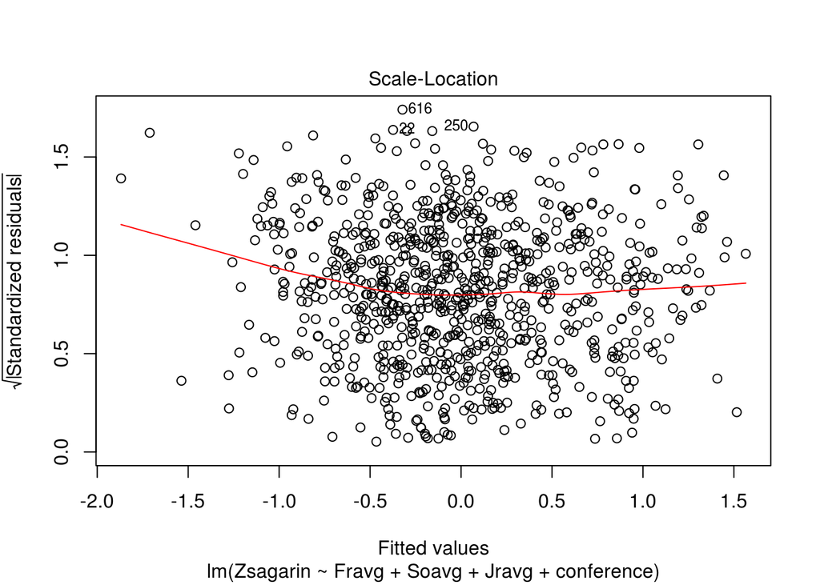

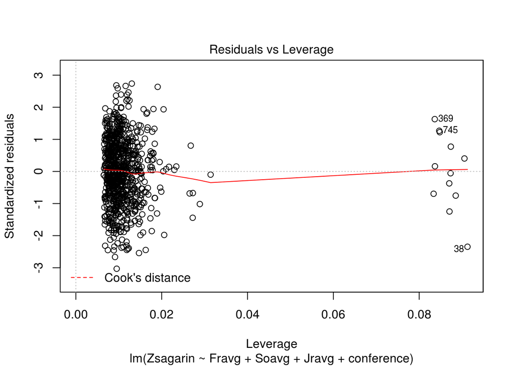

```r
plot(CFmr2)
```

I like the way that the above plots look for the most part. However, in the Residuals vs Fitted, Scale-Location and in the Residuals vs Leverage Plots I do see a slight decrease at the beginning but then it levels out. I would like to see if I could make it a straight line all the way across not just from the halfway point going forward.

```r
CFmr3 <- lm(Zsagarin ~ Fravg + Jravg + Soavg:coachexp_school, data = CF)
summary(CFmr3)
```

```
##
## Call:
## lm(formula = Zsagarin ~ Fravg + Jravg + Soavg:coachexp_school,
##     data = CF)
##
## Residuals:
##      Min       1Q   Median       3Q      Max
## -2.56092 -0.53650  0.00074  0.54671  2.28171
##
## Coefficients:
##                        Estimate Std. Error t value Pr(>|t|)
## (Intercept)           -3.938514   0.194535 -20.246  < 2e-16 ***
## Fravg                  0.901885   0.103316   8.729  < 2e-16 ***
## Jravg                  0.369086   0.103288   3.573 0.000372 ***
## Soavg:coachexp_school  0.008915   0.001512   5.897 5.32e-09 ***
## ---
## Signif. codes:  0 '***' 0.001 '**' 0.01 '*' 0.05 '.' 0.1 ' ' 1
##
## Residual standard error: 0.7879 on 853 degrees of freedom
## Multiple R-squared:  0.3614, Adjusted R-squared:  0.3591
## F-statistic: 160.9 on 3 and 853 DF,  p-value: < 2.2e-16
```

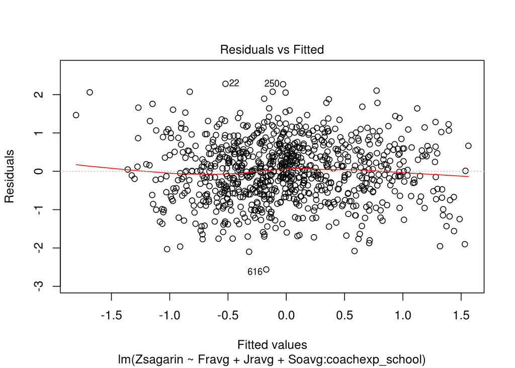

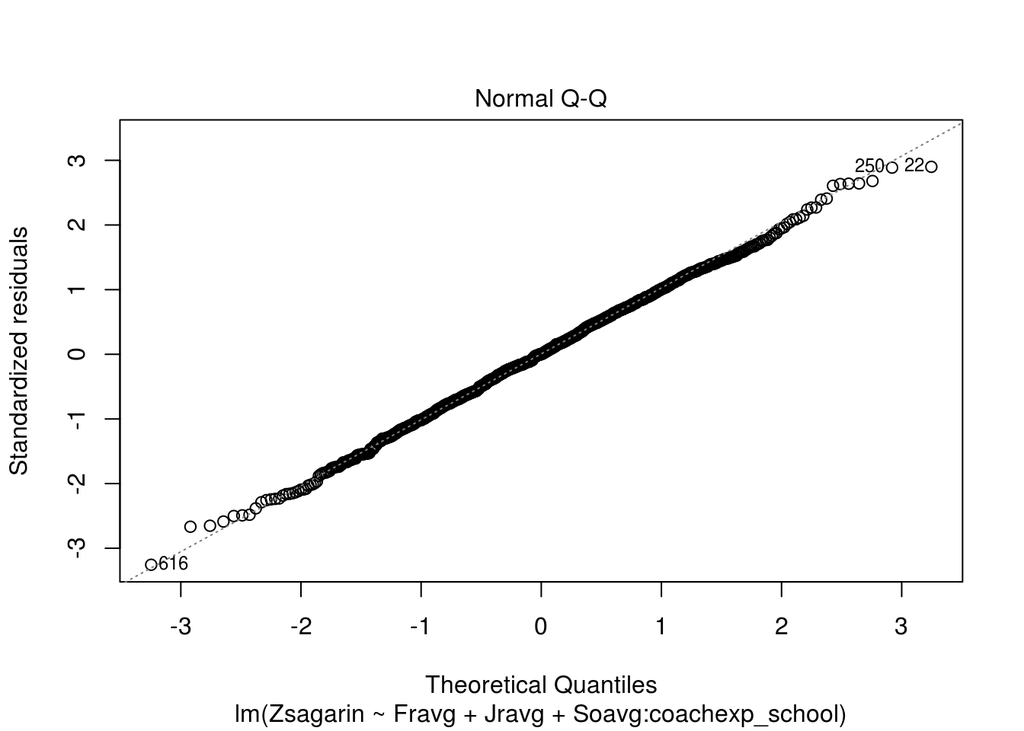

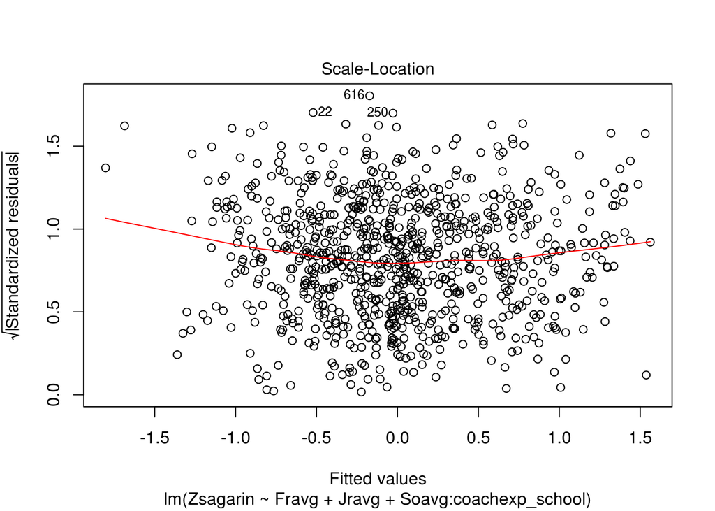

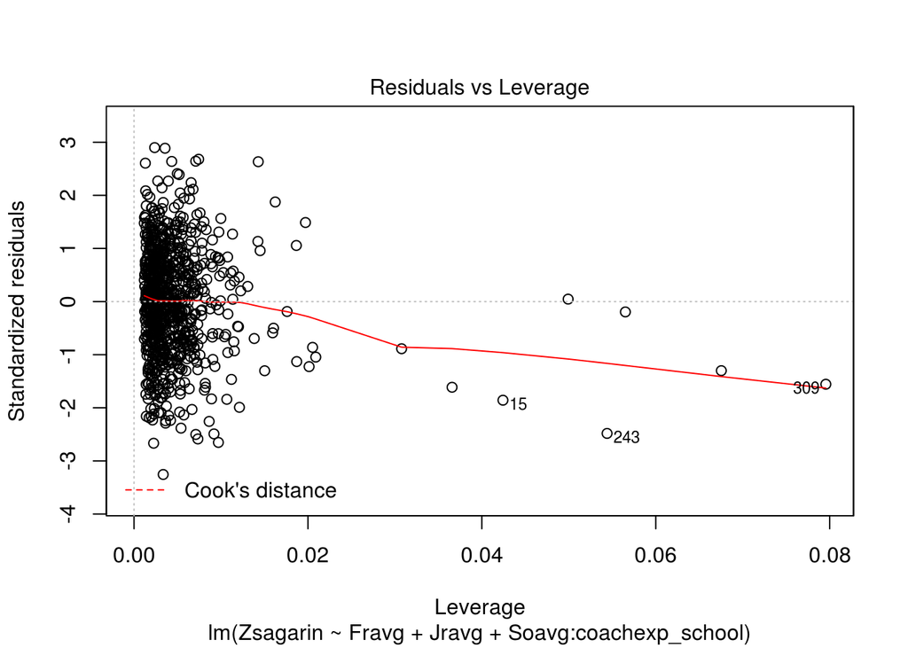

```r
plot(CFmr3)
```

```r
CFmr2 <- lm(Zsagarin ~ Fravg + Soavg + Jravg + conference, data = CF)
summary(CFmr2)
```

```
##
## Call:
## lm(formula = Zsagarin ~ Fravg + Soavg + Jravg + conference, data = CF)
##
## Residuals:
##      Min       1Q   Median       3Q      Max
## -2.41084 -0.54008  0.00379  0.56381  2.17361
##
## Coefficients:
##                     Estimate Std. Error t value Pr(>|t|)
## (Intercept)         -4.24377    0.24313 -17.455  < 2e-16 ***
## Fravg                0.81348    0.12282   6.623 6.24e-11 ***
## Soavg                0.27514    0.13304   2.068   0.0389 *
## Jravg                0.29856    0.12250   2.437   0.0150 *
## conferenceBigeast    0.11930    0.10469   1.140   0.2548
## conferencebigten     0.02116    0.09142   0.231   0.8170
## conferencebigtwelve  0.24005    0.09536   2.517   0.0120 *
## conferenceInd       -0.33661    0.24372  -1.381   0.1676
## conferencepacten     0.05788    0.09407   0.615   0.5385
## conferenceSEC        0.12138    0.09312   1.304   0.1928
## ---
## Signif. codes:  0 '***' 0.001 '**' 0.01 '*' 0.05 '.' 0.1 ' ' 1
##
## Residual standard error: 0.7994 on 847 degrees of freedom
## Multiple R-squared:  0.3472, Adjusted R-squared:  0.3403
## F-statistic: 50.06 on 9 and 847 DF,  p-value: < 2.2e-16
```

I tried multiple things included power transformations but I ended up finding that the interaction terms seemed to benefit my R-squared value and lower my p-value more significantly. However, I ended up not adding an interaction term to the model due to it messing making the plots have some form of linearity to them. I played around with different interaction terms and from what I tested several had low p-values but most if not all made the plotss worse so I reverted back to my original model (CFmr2).

```r
donner <- read_xlsx("donner.xlsx")
```

```r
train <- sample(45, 30, replace = FALSE)
train
```

```
##  [1] 29 24 42 15 12 28 17 36 13 33  4 11 45 41  9  3 39  8 32 10 26 19 14 25 38
## [26] 31  1 30 22 40
```

```r
traindata <- donner[train,]
traindata
```

```
## # A tibble: 30 x 5
##    Name            Multifam   Sex   Age Survived
##    <chr>              <dbl> <dbl> <dbl>    <dbl>
##  1 McCutcheon Ama         1     1    24        1
##  2 Hardkoop Mr            0     0    60        0
##  3 Stanton Charles        0     0    35        0
##  4 Fosdick Sarah          1     1    22        1
##  5 Eddy William           1     0    28        1
##  6 Keseberg Phine         1     1    32        1
##  7 Foster William         1     0    28        1
##  8 Reed Margaret          1     1    32        1
##  9 Elliot Milton          0     0    28        0
## 10 Pike Harriet           1     1    21        1
## # … with 20 more rows
```

```r
testdata <- donner[-train,]
testdata
```

```
## # A tibble: 15 x 5
##    Name            Multifam   Sex   Age Survived
##    <chr>              <dbl> <dbl> <dbl>    <dbl>
##  1 Breen Mary             1     1    40        1
##  2 Denton John            0     0    28        0
##  3 Dolan Patrick          0     0    40        0
##  4 Donner Eliz            1     1    45        0
##  5 Foster Sarah           1     1    23        1
##  6 Graves Eleanor         1     1    15        1
##  7 Graves Franklin        1     0    57        0
##  8 Graves Mary            1     1    20        1
##  9 Halloran Luke          0     0    25        0
## 10 Keseberg Lewis         1     0    32        1
## 11 Pike William           1     0    25        0
## 12 Reed James             1     0    46        1
## 13 Reinhardt Josep        0     0    30        0
## 14 Trubode J.B.           0     0    23        1
## 15 Williams Baylis        1     0    24        0
```

```r
training <- glm(Survived ~ Multifam + Sex + Age,family=binomial(link='logit'),data=traindata)
summary(training)
```

```
##
## Call:
## glm(formula = Survived ~ Multifam + Sex + Age, family = binomial(link = "logit"),
##     data = traindata)
##
## Deviance Residuals:
##     Min       1Q   Median       3Q      Max
## -2.1074  -0.7018  -0.3208   0.8386   1.7447
##
## Coefficients:
##             Estimate Std. Error z value Pr(>|z|)
## (Intercept)  1.32874    1.52302   0.872   0.3830
## Multifam     2.33953    1.18859   1.968   0.0490 *
## Sex          0.16376    1.13304   0.145   0.8851
## Age         -0.10417    0.05025  -2.073   0.0382 *
## ---
## Signif. codes:  0 '***' 0.001 '**' 0.01 '*' 0.05 '.' 0.1 ' ' 1
##
## (Dispersion parameter for binomial family taken to be 1)
##
##     Null deviance: 41.054  on 29  degrees of freedom
## Residual deviance: 29.327  on 26  degrees of freedom
## AIC: 37.327
##
## Number of Fisher Scoring iterations: 5
```

```r
probabilities <- predict(training, testdata, type = "response")
probabilities
```

```
##          1          2          3          4          5          6          7
## 0.41703056 0.16964257 0.05529125 0.29820711 0.80783431 0.90631074 0.09366276
##          8          9         10         11         12         13         14
## 0.85176653 0.21829371 0.58289355 0.74343281 0.24530964 0.14227613 0.25591922
##         15
## 0.76279468
```

```r
prediction <- rep("Did Not Survive", 15)
prediction[probabilities > 0.5] <- "Survived"


table(prediction, testdata$Survived)
```

```
##
## prediction        0 1
##   Did Not Survive 6 3
##   Survived        2 4
```

```r
library(class)

trainingindex <- sample(nrow(donner), nrow(traindata), replace = FALSE)

train <- cbind(donner$Multifam, donner$Sex, donner$Age)[trainingindex, ]

test <- cbind(donner$Multifam, donner$Sex, donner$Age)[-trainingindex, ]

class <- donner$Survived[trainingindex]

knnpred <- knn(train, test, class, k = 1)

knnpred <- factor(ifelse(knnpred == 1, "Survived", "Died"))
table(knnpred, testdata$Survived)
```

```
##
## knnpred    0 1
##   Died     4 6
##   Survived 4 1
```